# Y3865991

Daniel Sproston

# 1 Introduction

The purpose of this script is to efficiently import the data, ensure it is tidy, and explore whether the hypothesis may be true. The methods should be sufficiently explained, with data visualization and ensuring the following script can be replicated on Github.

## 1.2 The Data:

The specific data included [Holden2019-ok] was collected from the Yorkshare VLE, a student webpage accessible to members of York University. It was obtained on the VLE for convenience sake, as the [Holden2019-ok] did not include a version of the data that was directly transferable to Rstudio.

### 1.2.1 Column Description

Similar ITS2 sequences are grouped into an Operational Taxonomic Unit (OTU). The first column of the war imported data (OTU) represents each OTU/fungal species.

Each column beginning with a W represents a different environmental sample well, with the lists being number of sequence reads corresponding to a particular OTU.

Sums are all wells put to a specific OTU reference.

Taxonomy is self explanatory.

P.value represents the significance of match of sample to closest OTU.

Sequence was the specific OTU sequence.

(There are many NA values, which (according to the dataset author) correspond to samples with no significant OTU match, due potentially to: 1. Sequences might might still be fungal, but still divergent from any known reference ITS2 2. The sequencing may be low quality 3. The sequences themselves may be contaminated with non fungal origin.)

### 1.2.2 Data Tydying

```
## [1] 939  53
```

We can check whether each column is set as factors, numeric, integers, ect. However, since there are 53 variables, most of them being the sample wells, we should perform “str()” on a dataset with fewer WELL columns.

```
## 'data.frame':    939 obs. of  7 variables:
##  $ ï..OUT   : chr  "OTU.W36.543937" "OTU.W25.265387" "OTU.W14.3337" "OTU.W25.265241" ...
##  $ W14      : int  0 0 47 0 0 0 0 0 0 0 ...
##  $ sum      : int  4 166 10643 32 20 10 25 50 57 20 ...
##  $ taxonomy : chr  "k__Fungi;p__Ascomycota;c__Dothideomycetes;o__Botryosphaeriales;f__Botryosphaeriaceae;g__Diplodia;s__Diplodia_subglobosa" "k__Fungi;p__Ascomycota;c__Dothideomycetes;o__Capnodiales;f__Capnodiales_fam_Incertae_sedis;g__Vermiconia;s__Ver"| __truncated__ "k__Fungi;p__Ascomycota;c__…
##  $ p.value  : num  1e-126 5e-110 5e-113 9e-118 8e-112 ...
##  $ something: chr  "SH419951.07FU_GQ923856_refs" "SH585084.07FU_KP791759_refs" "SH422672.07FU_HM148090_refs" "SH127902.07FU_DQ780364_refs" ...
##  $ sequence : chr  "AACGCACATTGCGCCCCTTGGCATTCCGAGGGGCATGCCTGTTCGAGCGTCATTACAACCCTCAAGCTCTGCTTGGTATTGGGCGCCGTCCTCTCTGCGGACGCGCCTTAA"| __truncated__ "AACGCACATTGCGCCCCTTGGTATTCCGGGGGGCATGCCCGTTCGAGCGTCATTACACCACTCAAGCCTGGCTTGGTATTGGGCGTCCGGCACTCACCTGCCCGCCCCAAA"| __truncated__ "AACGCACATTGCGCCCCCT…
```

Now the output doesn’t look as messy, ans shows us the format of each column, which will become especially useful later when visualizing the data. We are of course assuming that all other wells are in the same format as “W14” (which they are, but for representational purposes in knit format, they are not included), and you are welcome to run “str(ITS_counts)” for validation if you wish.

We can now check the data is in tidy format.

If we look at the data, the taxonomy column technically includes several variables (species, genus, family ect). We can therefore split the taxonomy into individual classification ranks.

Despite the ugly “k_” characterization before the real value, each taxonomic variable now has its own column. The “well count” values are split into many columns, despite it being one variable. We can put all counts into one column, by assigning “well” as one variable, and resulting in “counts” being the other. This will cause a lot more repeating rows, but will make the data easier to analyse.

To confirm we have accurately tidied the data, we can repeat the “dim” function, to check we have only 14 columns and 44133 rows. It should be noted that should we wish to use the “sum” column for data visualization or analysis later, it would be more practical to revert back to the original data format (as the tidy format has many repeating “sum” values).

```
## 'data.frame':    44133 obs. of  14 variables:
##  $ ï..OUT   : chr  "OTU.W36.543937" "OTU.W25.265387" "OTU.W14.3337" "OTU.W25.265241" ...
##  $ sum      : int  4 166 10643 32 20 10 25 50 57 20 ...
##  $ Kingdom  : chr  "k__Fungi" "k__Fungi" "k__Fungi" "k__Fungi" ...
##  $ Phylum   : chr  "p__Ascomycota" "p__Ascomycota" "p__Ascomycota" "p__Ascomycota" ...
##  $ Class    : chr  "c__Dothideomycetes" "c__Dothideomycetes" "c__Dothideomycetes" "c__Dothideomycetes" ...
##  $ Order    : chr  "o__Botryosphaeriales" "o__Capnodiales" "o__Capnodiales" "o__Capnodiales" ...
##  $ Family   : chr  "f__Botryosphaeriaceae" "f__Capnodiales_fam_Incertae_sedis" "f__Cladosporiaceae" "f__Cladosporiaceae" ...
##  $ Genus    : chr  "g__Diplodia" "g__Vermiconia" "g__Cladosporium" "g__Cladosporium" ...
##  $ Species  : chr  "s__Diplodia_subglobosa" "s__Vermiconia_calcicola" "s__Cladosporium_exasperatum" "s__Cladosporium_halotolerans" ...
##  $ p.value  : num  1e-126 5e-110 5e-113 9e-118 8e-112 ...
##  $ something: chr  "SH419951.07FU_GQ923856_refs" "SH585084.07FU_KP791759_refs" "SH422672.07FU_HM148090_refs" "SH127902.07FU_DQ780364_refs" ...
##  $ sequence : chr  "AACGCACATTGCGCCCCTTGGCATTCCGAGGGGCATGCCTGTTCGAGCGTCATTACAACCCTCAAGCTCTGCTTGGTATTGGGCGCCGTCCTCTCTGCGGACGCGCCTTAA"| __truncated__ "AACGCACATTGCGCCCCTTGGTATTCCGGGGGGCATGCCCGTTCGAGCGTCATTACACCACTCAAGCCTGGCTTGGTATTGGGCGTCCGGCACTCACCTGCCCGCCCCAAA"| __truncated__ "AACGCACATTGCGCCCCCT…
##  $ Well     : chr  "W14" "W14" "W14" "W14" ...
##  $ Count    : int  0 0 47 0 0 0 0 0 0 0 ...
```

```
## [1] 44133    14
```

The data should not be imported and tidy.

```
## 'data.frame':    44133 obs. of  13 variables:
##  $ OTU     : Factor w/ 939 levels "OTU.W14.10025",..: 569 450 115 445 384 552 363 750 614 303 ...
##  $ sum     : num  4 166 10643 32 20 ...
##  $ Kingdom : Factor w/ 2 levels "k__Fungi","k__Protista": 1 1 1 1 1 1 1 1 1 1 ...
##  $ Phylum  : Factor w/ 14 levels "p__Ascomycota",..: 1 1 1 1 1 1 1 1 1 1 ...
##  $ Class   : Factor w/ 32 levels "c__Agaricomycetes",..: 5 5 5 5 5 5 5 5 5 5 ...
##  $ Order   : Factor w/ 87 levels "o__Agaricales",..: 10 14 14 14 14 14 14 14 23 24 ...
##  $ Family  : Factor w/ 163 levels "f__Agaricaceae",..: 19 23 31 31 93 93 156 156 49 48 ...
##  $ Genus   : Factor w/ 271 levels "g__Acephala",..: 86 260 51 51 157 258 258 258 20 28 ...
##  $ Species : Factor w/ 348 levels "s__Acephala_applanata",..: 115 336 61 62 215 334 334 334 28 36 ...
##  $ p.value : num  1e-126 5e-110 5e-113 9e-118 8e-112 ...
##  $ sequence: Factor w/ 939 levels "AACGCAAATGGCACTCTATGGTATTCCGTAGAGTACGTCTGTTTGAGCGTCGCGAACATCTCCATAATTAGTTTTTTAAATTAATTAAGGGTTTTGAGGTTGTCATTGTAT"| __truncated__,..: 194 274 169 170 484 171 196 544 259 533 ...
##  $ Well    : Factor w/ 47 levels "W03","W06","W08",..: 5 5 5 5 5 5 5 5 5 5 ...
##  $ Count   : num  0 0 47 0 0 0 0 0 0 0 ...
```

We can now import a second dataset that includes information regarding where the Well samples were collected, and will then collate the two datasets.

# 2 Data analysis

With the OTU samples, and locations collected now all in one dataframe, we can visualise the data for a clearer understanding of whether our hypothesis is correct.

# 3 Visualization

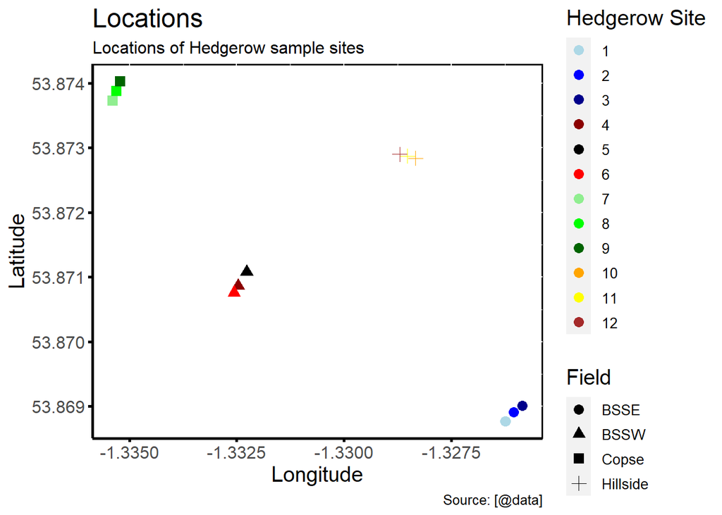

Figure 3.1: Field locations

The above graph displays where the Hedgerow samples were located. The coloring of this graph should help when we refer which well came from which Hedgerow sample.

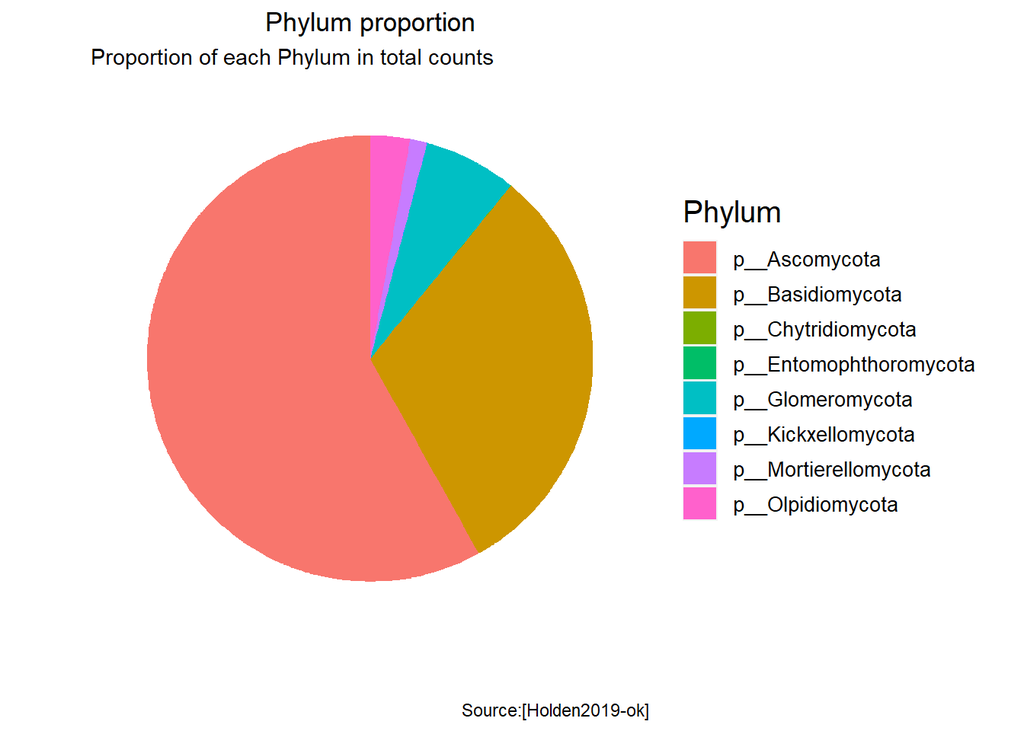

Figure 3.2: Pie chart of Phylum proportions

The pie chart summarises the proportion of phylum

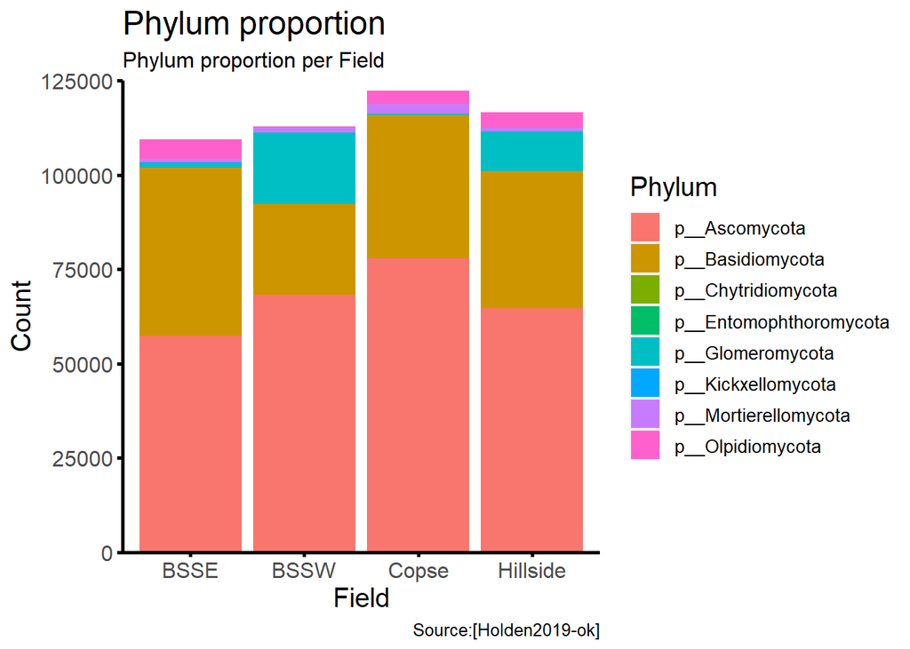

Figure 3.3: Phylum diversity by field

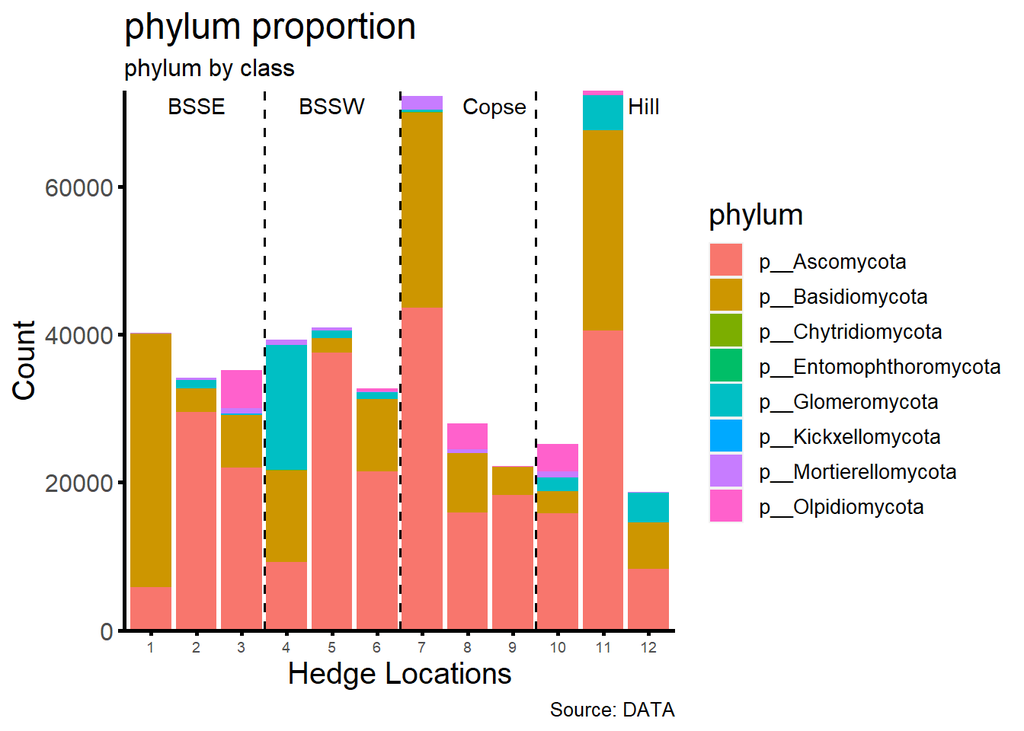

The stacked barplot gives a clearer summary of the proportion of phylum per field. However, to get a clearer view of this in geographical context, we can look at the individual hedge sites, and apply the stacked chart by phylum before to EACH individual collection site, for a more practical context of where the variety is.

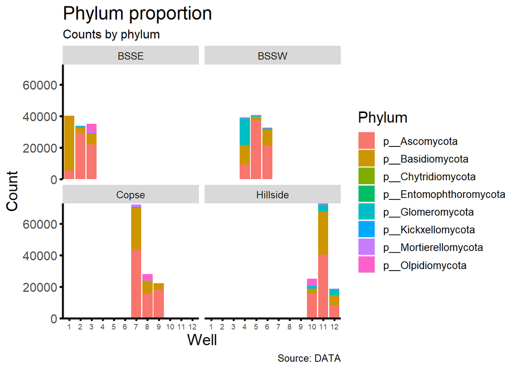

Figure 3.5: Phylum proportion by field comparison

# 4 statistical analysis

```
##  [1] "k__Fungi;p__Ascomycota"          "k__Fungi;p__Basidiomycota"
##  [3] "k__Fungi;p__Chytridiomycota"     "k__Fungi;p__Entomophthoromycota"
##  [5] "k__Fungi;p__Glomeromycota"       "k__Fungi;p__GS19"
##  [7] "k__Fungi;p__Kickxellomycota"     "k__Fungi;p__Mortierellomycota"
##  [9] "k__Fungi;p__Mucoromycota"        "k__Fungi;p__Olpidiomycota"
## [11] "k__Fungi;p__Rozellomycota"       "k__Fungi;p__unidentified"
## [13] "k__Fungi;p__Zoopagomycota"       "k__Protista;p__Cercozoa"
## [15] NA
```

[output not shown]

[output cut: 64 more lines]

```
##  [1] 926 927 928 929 930 931 932 933 934 935 936 937 938 939
```

```
##          k__Fungi;p__Ascomycota       k__Fungi;p__Basidiomycota
##                          739935                          203335
##     k__Fungi;p__Chytridiomycota k__Fungi;p__Entomophthoromycota
##                            1644                              20
##       k__Fungi;p__Glomeromycota                k__Fungi;p__GS19
##                           61131                              28
##     k__Fungi;p__Kickxellomycota   k__Fungi;p__Mortierellomycota
##                             131                            5698
##        k__Fungi;p__Mucoromycota       k__Fungi;p__Olpidiomycota
##                              92                           13352
##       k__Fungi;p__Rozellomycota        k__Fungi;p__unidentified
##                            3264                            3800
##       k__Fungi;p__Zoopagomycota         k__Protista;p__Cercozoa
##                            1986                             276
##                           other
##                            1026
```

```
##  [1] "W14" "W17" "W18" "W19" "W22" "W23" "W24" "W25" "W26" "W27" "W28" "W33"
## [13] "W34" "W35" "W36" "W03" "W41" "W42" "W43" "W44" "W50" "W51" "W52" "W53"
## [25] "W58" "W59" "W60" "W61" "W65" "W66" "W69" "W06" "W70" "W73" "W74" "W76"
## [37] "W77" "W79" "W81" "W83" "W85" "W86" "W87" "W89" "W08" "W95" "W09"
```

```
##
##  Pearson's Chi-squared test
##
## data:  hedgerow_counts_by_phylum
## X-squared = 804578, df = 644, p-value < 2.2e-16
```

```
## [1] 0.4184397
```

Degrees of freedom 644, p value <0.05, so significant. We can reject the null hypothesis, so Phylum and location are not independent, so diversity is associated.

```
##        W14        W17        W18        W19        W22        W23        W24
## 0.49807288 0.16762914 0.20365149 0.32745844 0.33475559 0.33443232 0.15291603
##        W25        W26        W27        W28        W33        W34        W35
## 0.57822915 0.57717751 0.46502694 0.57514129 0.06508104 0.09464753 0.22801737
##        W36        W03        W41        W42        W43        W44        W50
## 0.18903588 0.56936660 0.00000000 0.42078375 0.43765607 0.49588258 0.30263233
##        W51        W52        W53        W58        W59        W60        W61
## 0.08393509 0.49390262 0.41267318 0.36155131 0.33054538 0.19056867 0.31051566
##        W65        W66        W69        W06        W70        W73        W74
## 0.18836565 0.10858469 0.19968855 0.45407865 0.02029461 0.43566361 0.37081157
##        W76        W77        W79        W81        W83        W85        W86
## 0.21508357 0.52838941 0.32021222 0.49288508 0.56722568 0.50000000 0.38121734
##        W87        W89        W08        W95        W09
## 0.51108194 0.55993412 0.02184443 0.57841302 0.25865596
```

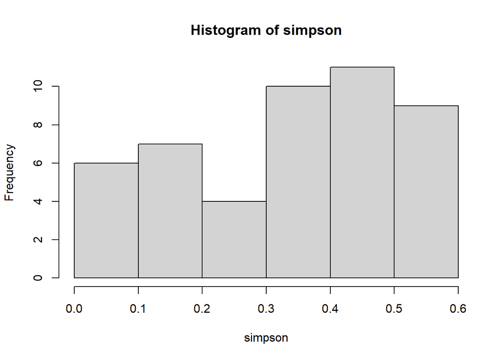

```
## $BSSE
##       W14       W17       W18       W19       W22       W23       W24       W25
## 0.4980729 0.1676291 0.2036515 0.3274584 0.3347556 0.3344323 0.1529160 0.5782291
##       W26       W27       W28
## 0.5771775 0.4650269 0.5751413
##
## $BSSW
##        W33        W34        W35        W36        W03        W41        W42
## 0.06508104 0.09464753 0.22801737 0.18903588 0.56936660 0.00000000 0.42078375
##        W43        W44        W50        W51        W52
## 0.43765607 0.49588258 0.30263233 0.08393509 0.49390262
##
## $Copse
##        W53        W58        W59        W60        W61        W65        W66
## 0.41267318 0.36155131 0.33054538 0.19056867 0.31051566 0.18836565 0.10858469
##        W69        W06        W70        W73        W74
## 0.19968855 0.45407865 0.02029461 0.43566361 0.37081157
##
## $Hillside
##        W76        W77        W79        W81        W83        W85        W86
## 0.21508357 0.52838941 0.32021222 0.49288508 0.56722568 0.50000000 0.38121734
##        W87        W89        W08        W95        W09
## 0.51108194 0.55993412 0.02184443 0.57841302 0.25865596
```

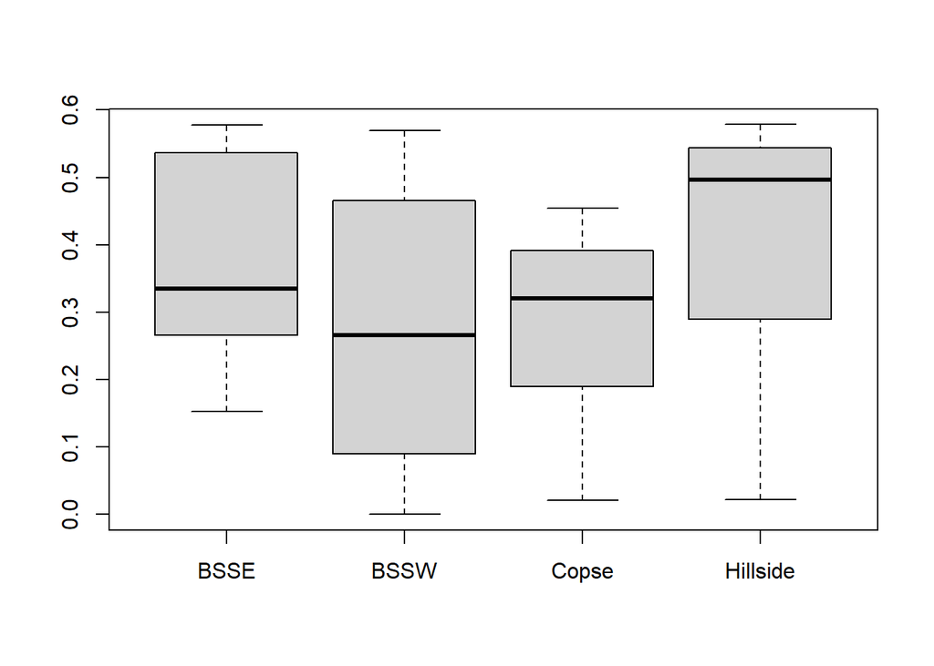

```
##        W14        W17        W18        W19        W22        W23        W24
## 0.49807288 0.16762914 0.20365149 0.32745844 0.33475559 0.33443232 0.15291603
##        W25        W26        W27        W28        W33        W34        W35
## 0.57822915 0.57717751 0.46502694 0.57514129 0.06508104 0.09464753 0.22801737
##        W36        W03        W41        W42        W43        W44        W50
## 0.18903588 0.56936660 0.00000000 0.42078375 0.43765607 0.49588258 0.30263233
##        W51        W52        W53        W58        W59        W60        W61
## 0.08393509 0.49390262 0.41267318 0.36155131 0.33054538 0.19056867 0.31051566
##        W65        W66        W69        W06        W70        W73        W74
## 0.18836565 0.10858469 0.19968855 0.45407865 0.02029461 0.43566361 0.37081157
##        W76        W77        W79        W81        W83        W85        W86
## 0.21508357 0.52838941 0.32021222 0.49288508 0.56722568 0.50000000 0.38121734
##        W87        W89        W08        W95        W09
## 0.51108194 0.55993412 0.02184443 0.57841302 0.25865596
```

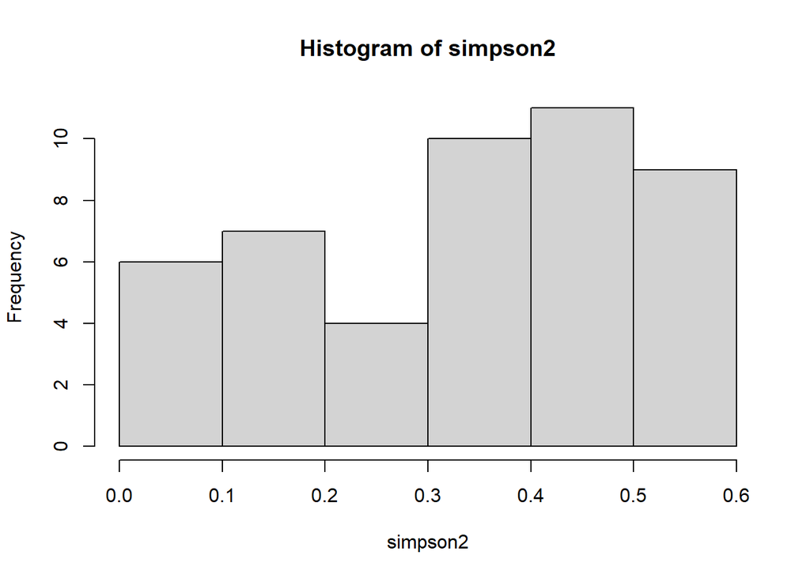

```
##    W03.W14    W06.W17    W08.W18    W09.W19    W14.W22    W17.W23    W18.W24
## 0.49807288 0.16762914 0.20365149 0.32745844 0.33475559 0.33443232 0.15291603
##    W19.W25    W22.W26    W23.W27    W24.W28    W25.W33    W26.W34    W27.W35
## 0.57822915 0.57717751 0.46502694 0.57514129 0.06508104 0.09464753 0.22801737
##    W28.W36    W33.W03    W34.W41    W35.W42    W36.W43    W41.W44    W42.W50
## 0.18903588 0.56936660 0.00000000 0.42078375 0.43765607 0.49588258 0.30263233
##    W43.W51    W44.W52    W50.W53    W51.W58    W52.W59    W53.W60    W58.W61
## 0.08393509 0.49390262 0.41267318 0.36155131 0.33054538 0.19056867 0.31051566
##    W59.W65    W60.W66    W61.W69    W65.W06    W66.W70    W69.W73    W70.W74
## 0.18836565 0.10858469 0.19968855 0.45407865 0.02029461 0.43566361 0.37081157
##    W73.W76    W74.W77    W76.W79    W77.W81    W79.W83    W81.W85    W83.W86
## 0.21508357 0.52838941 0.32021222 0.49288508 0.56722568 0.50000000 0.38121734
##    W85.W87    W86.W89    W87.W08    W89.W95    W95.W09
## 0.51108194 0.55993412 0.02184443 0.57841302 0.25865596
```

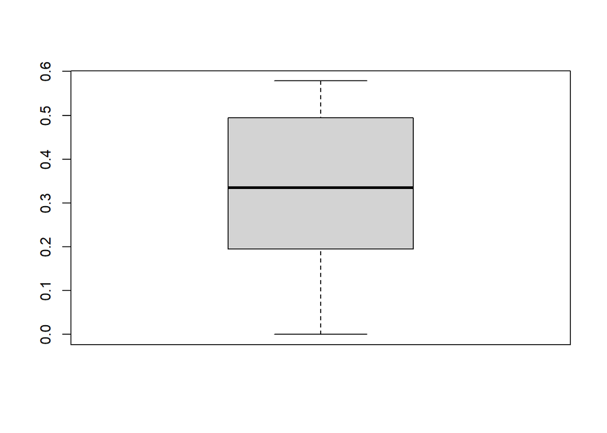

simpson values, higher values mean better diversity - therefore the values of each well range significantly. For more specific results we can look more at simpson phylum by field and running an anova to comapre them. Since a Simpson diversity field is mainly useful when comparing fields statistically, Simpson is not that useful on its own.

```
##    Well    Simpson
## 1   W14 0.49807288
## 2   W17 0.16762914
## 3   W18 0.20365149
## 4   W19 0.32745844
## 5   W22 0.33475559
## 6   W23 0.33443232
## 7   W24 0.15291603
## 8   W25 0.57822915
## 9   W26 0.57717751
## 10  W27 0.46502694
## 11  W28 0.57514129
## 12  W33 0.06508104
## 13  W34 0.09464753
## 14  W35 0.22801737
```

[output cut: 33 more lines]

```
##    Well    Simpson    Field HedgeLocation Root.number Latitude Longitude
## 1   W03 0.56936660     BSSE             1           3 53.86877 -1.326241
## 2   W06 0.45407865     BSSE             1           6 53.86877 -1.326242
## 3   W08 0.02184443     BSSE             1           8 53.86877 -1.326243
## 4   W09 0.25865596     BSSE             2           9 53.86891 -1.326051
## 5   W14 0.49807288     BSSE             2          14 53.86891 -1.326052
## 6   W17 0.16762914     BSSE             3          17 53.86901 -1.325844
## 7   W18 0.20365149     BSSE             3          18 53.86901 -1.325845
## 8   W19 0.32745844     BSSE             3          19 53.86901 -1.325846
## 9   W22 0.33475559     BSSE             3          22 53.86901 -1.325847
## 10  W23 0.33443232     BSSE             3          23 53.86901 -1.325848
## 11  W24 0.15291603     BSSE             3          24 53.86901 -1.325849
## 12  W25 0.57822915     BSSW             4          25 53.87087 -1.332464
## 13  W26 0.57717751     BSSW             4          26 53.87087 -1.332465
## 14  W27 0.46502694     BSSW             4          27 53.87087 -1.332466
```

[output cut: 33 more lines]

```
## Analysis of Variance Table
##
## Response: Simpson
##           Df  Sum Sq  Mean Sq F value  Pr(>F)
## Field      3 0.27143 0.090477  3.4189 0.02552 *
## Residuals 43 1.13795 0.026464
## ---
## Signif. codes:  0 '***' 0.001 '**' 0.01 '*' 0.05 '.' 0.1 ' ' 1
```

# 5 Conclusions

As we have seen by the results of the ANOVA, hopefully I can interpret what it means. Anover performed on linear model that predicts index diversity based on linear model of simpsons by field. P value = 0.02552 * so significant difference in diversity between fields then.

# 6 References

1. Bennett, E. M., Peterson, G. D. and Gordon, L. J. (2009). Understanding relationships among multiple ecosystem services. Ecology letters, 12 (12), pp.1394–1404.
2. Charif, D. et al. (2007). The seqinr Package. R Packag. [Online]. Available at: http://ftp.uni-bayreuth.de/math/statlib/R/CRAN/doc/packages/seqinr.pdf.
3. Holden, J. et al. (2017). Water quality and UK agriculture: challenges and opportunities. Wiley Interdisciplinary Reviews: Water, 4 (2), p.e1201. [Online]. Available at: doi:10.1002/wat2.1201.
4. Holden, J. et al. (2019). The role of hedgerows in soil functioning within agricultural landscapes. Agriculture, ecosystems & environment, 273, pp.1–12.
5. Jari Oksanen, F. G. B. et al. (2018). Vegan: community ecology package. R package version, 2 (6).
6. Mailund, T. (2019). Manipulating Data Frames: dplyr. In: Mailund, T. (Ed). R Data Science Quick Reference: A Pocket Guide to APIs, Libraries, and Packages. Berkeley, CA: Apress. pp.109–160.
7. Martin-Ortega, J. et al. (2015). Water ecosystem services: a global perspective. UNESCO Publishing.
8. Monokrousos, N. et al. (2006). Soil quality variables in organically and conventionally cultivated field sites. Soil biology & biochemistry, 38 (6), pp.1282–1289.
9. Ripley, B. and Others. (2011). MASS: support functions and datasets for Venables and Ripley’s MASS. R package version, 7, pp.3–29.
10. Silva, M. and Prince, M. E. (2008). The Conservation Value of Hedgerows for Small Mammals in Prince Edward Island, Canada. The American Midland Naturalist, 159 (1), pp.110–124. [Accessed 17 December 2020].
11. Soane, B. D. and van Ouwerkerk, C. (1995). Implications of soil compaction in crop production for the quality of the environment. Soil and Tillage Research, 35 (1-2), pp.5–22. [Online]. Available at: doi:10.1016/0167-1987(95)00475-8.
12. Tierney, N. et al. (2019). Naniar: data Structures, Summaries, and Visualisations for missing data. R Package.
13. Wickham, H. and Wickham, M. H. (2007). The ggplot package. [Online]. Available at: http://ftp.uni-bayreuth.de/math/statlib/R/CRAN/doc/packages/ggplot.pdf.
14. Wickham, H. and Wickham, M. H. (2017). Package ‘tidyr’. Easily Tidy Data with’spread’and’gather ()’Functions. [Online]. Available at: https://mran.microsoft.com/snapshot/2018-03-22/web/packages/tidyr/tidyr.pdf.